# Dougs Crime Analysis

Doug Walton

April 26, 2016

This document contains the code I am using to manipulate the demographic and crime files.

In this document, I explore using publically available data from various U.S. government sources and associated R packages to explore the question, “is the the rate of either homicide or rape associated with any identifiable demographic factors?” This will give insight into the research possibilities for using these datasets with this kind of social science question.

Some possible factors could be

```
1. Household type
2. age
3. sex
4. racial mix (white, black, hispanic)
5. education
6. individual income (median)
```

First, to get set up

```r
library(dplyr)
```

```r
library(tidyr)
library(ggplot2)
library(readr)
library(broom)
library(knitr)
```

# National Level

Starting with tables derived from the [2012 Statistical Abstract of the United States](http://www.census.gov/library/publications/2011/compendia/statab/131ed.html), I develop some views of the key factors.

1. us_national.csv is population by year from 1900 to 2015. initially derived from Section 1, Tables 1 & 2. Lagging zeros filled in on earlier years to make everything in consistent units (removed ’000s reduction). Added years 2010 to 2015 from PEPANNRES annual estimates of population (found through American Fact Finder.)

I then take selected chosen areas from different census tables to add to this national master.

2. Households in the US. According to the census data dictionary: “A household that has at least one member of the household related to the householder by birth, marriage, or adoption is a”Family household." Same-sex couple households are included in the family households category if there is at least one additional person related to the householder by birth or adoption. Same-sex couple households with no relatives of the householder present are tabulated in nonfamily households. Responses of “same-sex spouse” were edited during processing to “unmarried partner.” “Nonfamily households” consist of people living alone and households which do not have any members related to the householder."

A base table is constructed from the UC census table 12s0059.xls from the U.S. Statistical Abstract 2012, which covers 1960 to 2010, and then selected householder characteristics for 2011 to 2014 are added from the ACS files and B11001, B11001A, B11001I to create 12s0059-households.csv. (Tables can be found using American Fact Finder)

```r
# Starting with a base table US national population data by year from 1900
uspop <- read.csv("us_national.csv")
uspop$year <- as.character(uspop$year)

# Add household data and select out key types that might we worth looking at
# years 1960 to 2014
UShousehold <- read.csv("Sources/12s0059-households.csv")
UShousehold$Type.of.unit <- as.character(UShousehold$Type.of.unit)
UShousehold$Type.of.unit[3:9] <- c("Household_white","Household_black","Household_hispanic","fam_household","couple_household","male_household","fem_household")
UShousehold_s <- UShousehold %>% slice(1:9) %>% select(-X1960) # eliminate gap
cols <- UShousehold_s$Type.of.unit
UShousehold_s <- as.data.frame(t(UShousehold_s[,-1]))
colnames(UShousehold_s) <- cols
UShousehold_s <- add_rownames(UShousehold_s, "year")
# UShousehold$year <- as.factor(UShousehold$year)
usnat <- uspop %>% left_join(UShousehold_s, by = 'year')

# Add income data for age, sex, and major ethnic groups in 2009 dollars
# years 1947 to 2009
USincome <- read.csv("Sources/12s0701-median-income-2009-dollars.csv")
USincome$X <- as.character(USincome$X)
cols <- USincome$X
USincome_s <- as.data.frame(t(USincome[,-1]))
colnames(USincome_s) <- cols
USincome_s <- add_rownames(USincome_s, "year")
usnat <- usnat %>% left_join(USincome_s, by = 'year')

# Educational attainment 1960 to 2010 for age, sex, major ethnicity
USedu <- read.csv("Sources/12s0230-education.csv")
USedu$year <- as.character(USedu$year)
usnat <- usnat %>% left_join(USedu, by = 'year')

# Ppulation subgroups by ethnicity and sex 2000 to 2010
USbasic2010 <- read.csv("Sources/US-EST00INT-ALLDATA.csv")
USbasic2010 <- USbasic2010 %>% filter(AGE != '999' & MONTH != '4')
USbasic2010 <- USbasic2010[,-1]

USbasic2010sum <- USbasic2010 %>% group_by(YEAR) %>% summarise(tot_male = sum(TOT_MALE), tot_female = sum(TOT_FEMALE), white_male_pop = sum(WA_MALE),white_female_pop = sum(WA_FEMALE),black_male_pop = sum(BA_MALE),black_female_pop = sum(BA_FEMALE),hisp_male_pop = sum(H_MALE),hisp_female_pop = sum(H_FEMALE))


USbasic2010sum <- rename(USbasic2010sum, year = YEAR)
USbasic2010sum$year <- paste0("X",USbasic2010sum$year)
usnat <- usnat %>% left_join(USbasic2010sum, by = 'year')

# Adding homicide and rape data 1960 to 2012
UScrime <- read.csv("Sources/12s0306-tot_in_thousands_ofcrimetype1980-2009.csv")
UScrime$year <- paste0("X",UScrime$year)
UScrime[2:6] <- UScrime[2:6] * 100000
usnat2 <- usnat %>% left_join(UScrime, by = 'year')
```

As can be seen in the tables and commentary above, while there is a considerable amount of data available, compiling a longitudinal view is challenging because the data was collected in differing ways over decades, with differing assumptions and labels. Some of the data is already based on approximations by US census bureau, and to join the tables into a continous data series for decades involves further assumptions about how closely one category is like another. At a macro-level, this may not matter much for initially finding productive opportunities for research, but it is something to be kept in mind for later verification.

## The Big Picture Nationally

For a first pass, I explore the general trends for rape and homicide for the dataset we have by extracting the relevant years and converting the totals in the table to occurrances per 100,000 people to filter out the effect of general population growth and make the numbers more readable.

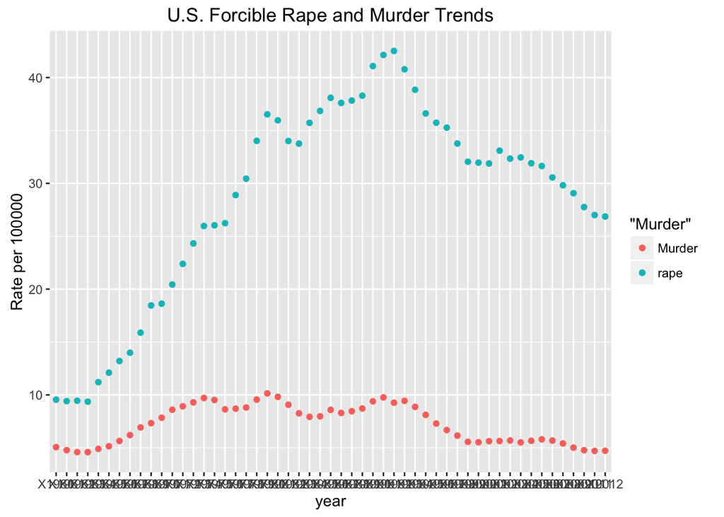

```r
# Making a sub table of just specific data of interest to make the data easier to manipulate and show
# households was in 1000s, crimes in total numbers
usnat_sub <- usnat2 %>% filter(year >= 'X1960' & year <= 'X2012') %>% mutate(murderpct = murder/residents*1000, rapepct = forcible_rape/residents*1000, housepct = (couple_household/residents)*1000)


# Graph of murders and rape trend over the last few decade
usnat_sub  %>% ggplot(aes(year)) + geom_point(aes(y = murderpct, col = "Murder")) + geom_point(aes(y=rapepct, col="rape")) + labs(title="U.S. Forcible Rape and Murder Trends", y = "Rate per 100000")
```

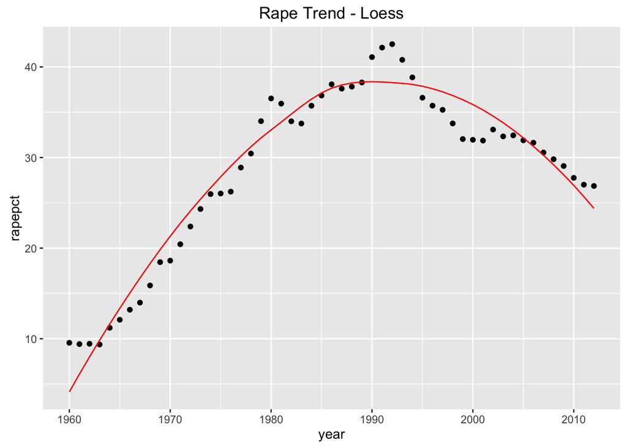

```r
# To take a close look at the rape trend
dat <- usnat_sub %>% select(year, rapepct,murderpct)
dat$year <- seq(1960,2012)

# fitting line to rape data using loess to see about the trend
mod <- loess(rapepct~year, degree=2, span = 1, data=dat)
loess_fit <- augment(mod)

dat %>% ggplot(aes(year)) + geom_point(aes(y=rapepct)) + geom_line(aes(x=year, y=.fitted), data=loess_fit, color="red") + labs(title="Rape Trend - Loess")
```

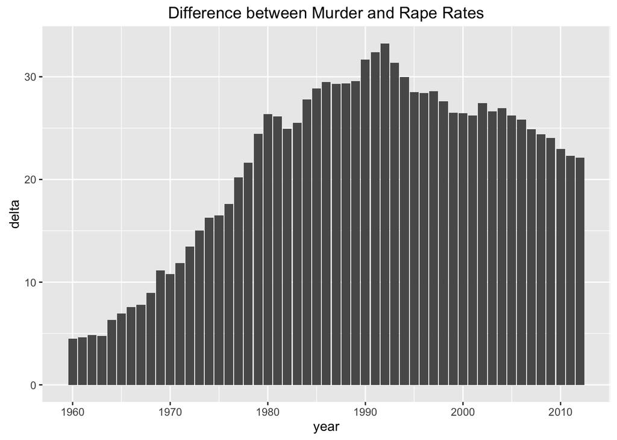

```r
# Since we are looking for demographic factors that might suggest rape rather than murder, here is the gap between the two

dat <- dat %>% mutate(delta = rapepct - murderpct)
dat %>% ggplot(aes(year,delta)) + geom_bar(stat = "identity") + labs(title = "Difference between Murder and Rape Rates")
```

So, taking a look at some factors that might account for it.

## Household Composition

Next, we explore the question of whether perhaps more “broken” or non-traditional male-female households could create an increase in crime. So for an indicator, the relationship of households in couples is compared against the the homicide and rape crime rates.

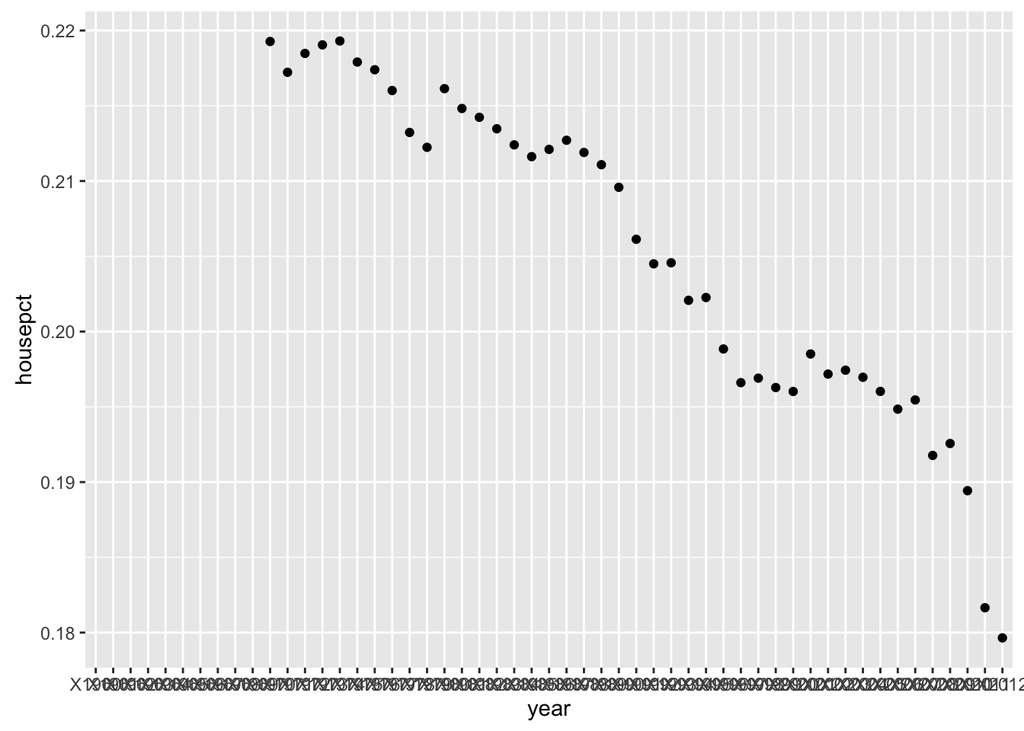

```r
# Couples over time
usnat_sub  %>% ggplot(aes(year,housepct)) + geom_point()
```

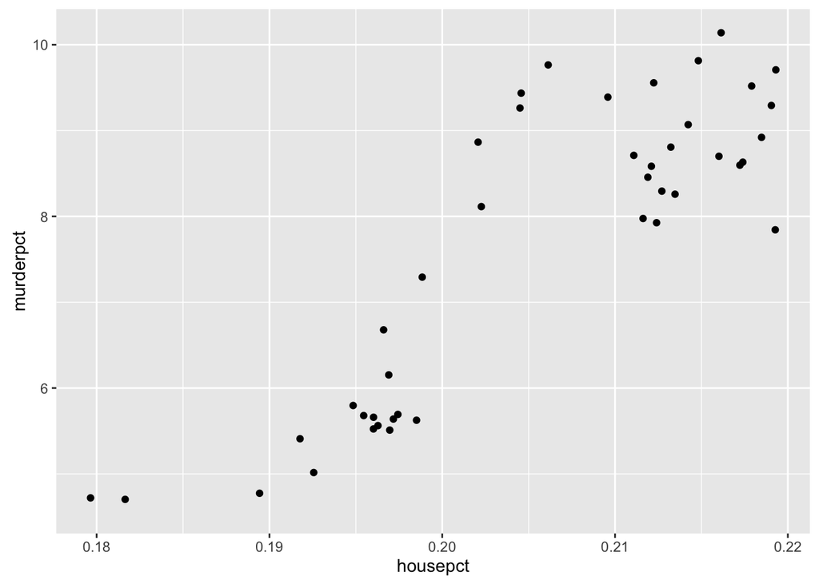

```r
# more murders with more couples?
usnat_sub %>% ggplot(aes(housepct,murderpct)) + geom_point()
```

```r
# usnat_sub  %>% ggplot(aes(year,rapepct)) + geom_point() + geom_point(aes(y = housepct))

# probably doesn't mean anything
cor(usnat_sub$murderpct,usnat_sub$housepct)
```

```
## [1] NA
```

```r
cor.test(usnat_sub$murderpct,usnat_sub$housepct)
```

```
##
##  Pearson's product-moment correlation
##
## data:  usnat_sub$murderpct and usnat_sub$housepct
## t = 11.094, df = 41, p-value = 6.399e-14
## alternative hypothesis: true correlation is not equal to 0
## 95 percent confidence interval:
##  0.7646433 0.9256469
## sample estimates:
##       cor
## 0.8660855
```

## Income and Educational Attainment

Moving on to take a look at some of the other factors we have.

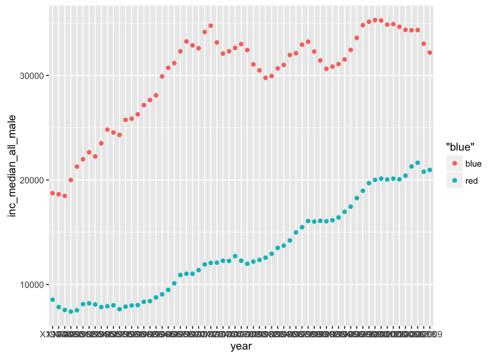

```r
# Incomes all Males vs All Females
USincome_s  %>% ggplot(aes(year)) + geom_point(aes(y=inc_median_all_male, col="blue")) + geom_point(aes(y=inc_median_all_female, col="red"))
```

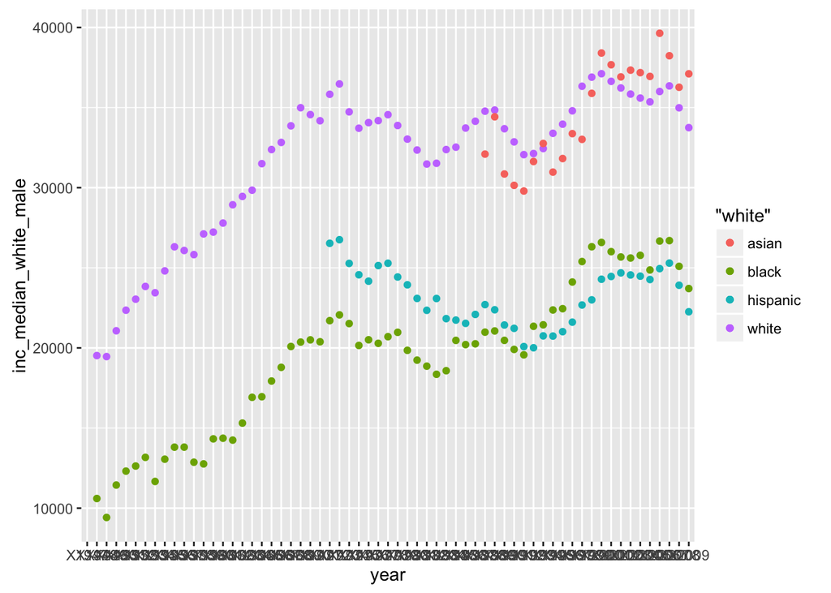

```r
# Incomes males in largest ethnic groups
USincome_s  %>% ggplot(aes(year)) + geom_point(aes(y=inc_median_white_male, col="white")) + geom_point(aes(y=inc_median_black_male, col="black")) + geom_point(aes(y=inc_median_asian_male, col="asian")) + geom_point(aes(y=inc_median_hispanic_male, col="hispanic"))
```

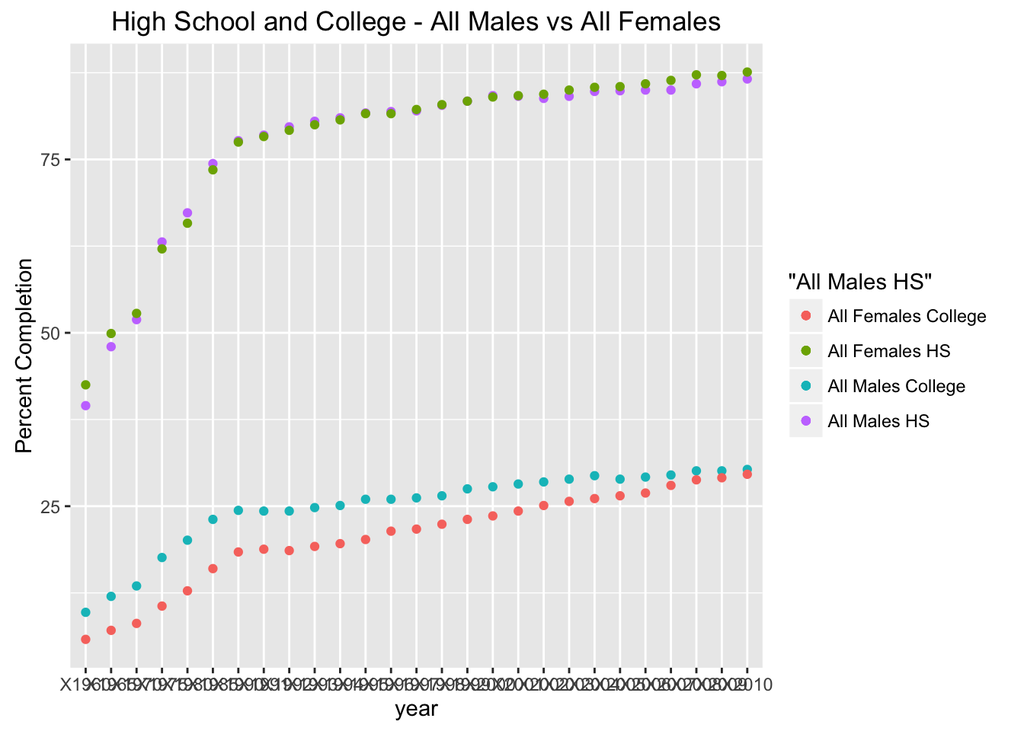

```r
# Educational attainment in High School and College of all males vs females
USedu  %>% ggplot(aes(year)) + geom_point(aes(y=hs.all.male, col="All Males HS")) + geom_point(aes(y=hs.all.female, col="All Females HS")) + geom_point(aes(y=col.all.male, col="All Males College")) + geom_point(aes(y=col.all.female, col="All Females College")) + labs(title="High School and College - All Males vs All Females", y="Percent Completion")
```

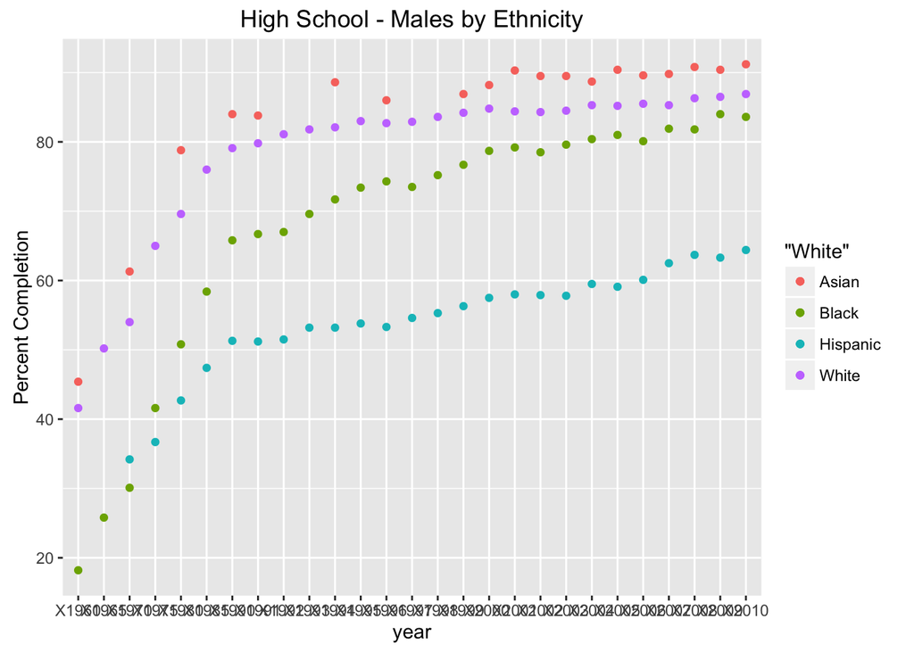

```r
# HS attainment males by ethnicity
USedu  %>% ggplot(aes(year)) + geom_point(aes(y=hs.white.male, col="White")) + geom_point(aes(y=hs.black.male, col="Black")) + geom_point(aes(y=hs.asian.male, col="Asian")) + geom_point(aes(y=hs.hisp.male, col="Hispanic")) + labs(title="High School - Males by Ethnicity", y="Percent Completion")
```

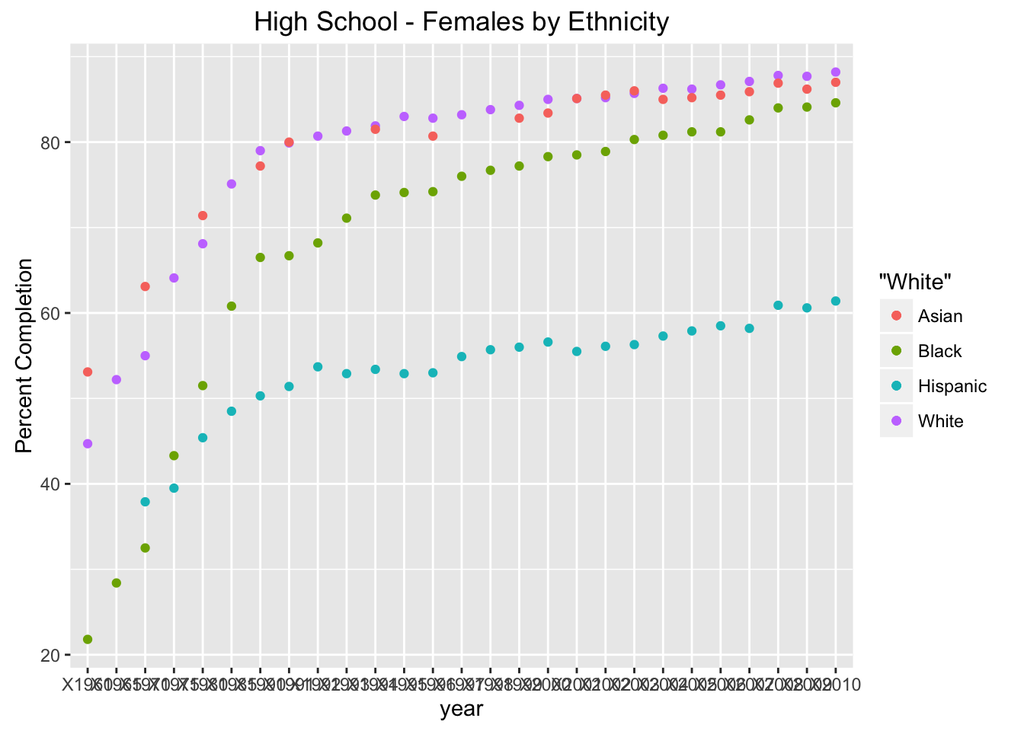

```r
# HS attainment females by ethnicity
USedu  %>% ggplot(aes(year)) + geom_point(aes(y=hs.white.female, col="White")) + geom_point(aes(y=hs.black.female, col="Black")) + geom_point(aes(y=hs.asian.female, col="Asian")) + geom_point(aes(y=hs.hisp.female, col="Hispanic")) + labs(title="High School - Females by Ethnicity", y="Percent Completion")
```

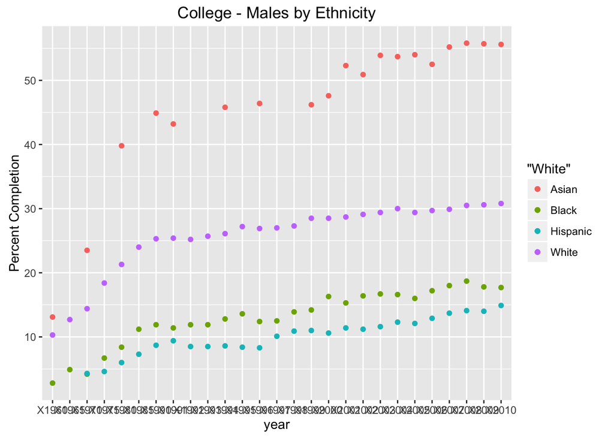

```r
# College attainment males by ethnicity
USedu  %>% ggplot(aes(year)) + geom_point(aes(y=col.white.male, col="White")) + geom_point(aes(y=col.black.male, col="Black")) + geom_point(aes(y=col.asian.male, col="Asian")) + geom_point(aes(y=col.hisp.male, col="Hispanic")) + labs(title="College - Males by Ethnicity", y="Percent Completion")
```

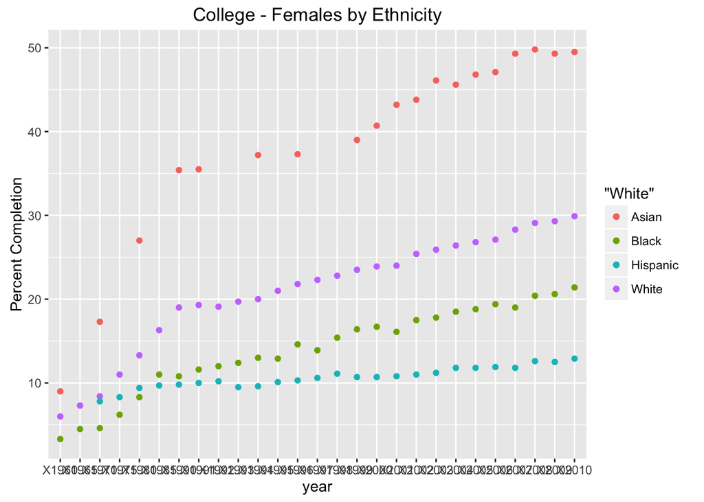

```r
# College attainment females by ethnicity
USedu  %>% ggplot(aes(year)) + geom_point(aes(y=col.white.female, col="White")) + geom_point(aes(y=col.black.female, col="Black")) + geom_point(aes(y=col.asian.female, col="Asian")) + geom_point(aes(y=col.hisp.female, col="Hispanic")) + labs(title="College - Females by Ethnicity", y="Percent Completion")
```

So there are some trends we can see, both educational attainment and income seem to rise along with the rising forcible rape rate, but they do not decline with it. Moroever, it seems likely that if these were factors, there would be some kind of time delay - for example, rising income wouldn’t deter rapists immediately and there seems to be no theory on how those factors might be related.

Is there a model of some of these key factors that would fit this? Here we take selected factors pertaining to traditional households, income, and educational attainment and try to fit a model. (glm or lm? not sure it makes a difference but maybe take a closer look)

```r
usnat_sub1 <- usnat2 %>% filter(year <= 'X2010' & year >= 'X2000') %>% mutate(murderpct = murder/(residents/1000), rapepct = forcible_rape/(residents/1000), housepct = (couple_household/residents)*1000)

# here a logisic regression is fit for murder.
fit <- usnat_sub1 %>% glm(murderpct ~ couple_household + inc_median_all_male + inc_median_all_female + hs.all.male + hs.all.female + col.all.male + col.all.female, data = .)
summary(fit)
```

```
##
## Call:
## glm(formula = murderpct ~ couple_household + inc_median_all_male +
##     inc_median_all_female + hs.all.male + hs.all.female + col.all.male +
##     col.all.female, data = .)
##
## Deviance Residuals:
##         2          3          4          5          6          7
## -0.090048   0.055250  -0.038053   0.018121   0.054425   0.098128
##         8          9         10
## -0.063257  -0.005178  -0.029387
##
## Coefficients:
##                         Estimate Std. Error t value Pr(>|t|)
## (Intercept)           -3.287e+01  4.677e+01  -0.703    0.610
## couple_household       9.378e-05  4.963e-04   0.189    0.881
## inc_median_all_male    1.275e-04  5.251e-04   0.243    0.848
## inc_median_all_female -7.282e-06  2.971e-04  -0.025    0.984
## hs.all.male           -4.059e-01  8.321e-01  -0.488    0.711
## hs.all.female          9.968e-01  1.565e+00   0.637    0.639
## col.all.male          -4.286e-01  5.557e-01  -0.771    0.582
## col.all.female        -3.611e-01  1.003e+00  -0.360    0.780
##
## (Dispersion parameter for gaussian family taken to be 0.03042075)
##
##     Null deviance: 0.429761  on 8  degrees of freedom
## Residual deviance: 0.030421  on 1  degrees of freedom
##   (2 observations deleted due to missingness)
## AIC: -7.6678
##
## Number of Fisher Scoring iterations: 2
```

```r
# here a logisic regression is fit for rape
fit <- usnat_sub1 %>% glm(rapepct ~ couple_household + inc_median_all_male + inc_median_all_female + hs.all.male + hs.all.female + col.all.male + col.all.female, data = .)
summary(fit)
```

```
##
## Call:
## glm(formula = rapepct ~ couple_household + inc_median_all_male +
##     inc_median_all_female + hs.all.male + hs.all.female + col.all.male +
##     col.all.female, data = .)
##
## Deviance Residuals:
##        2         3         4         5         6         7         8
## -0.63582   0.39011  -0.26869   0.12795   0.38429   0.69287  -0.44665
##        9        10
## -0.03656  -0.20750
##
## Coefficients:
##                         Estimate Std. Error t value Pr(>|t|)
## (Intercept)            9.278e+01  3.302e+02   0.281    0.826
## couple_household       2.423e-04  3.504e-03   0.069    0.956
## inc_median_all_male    7.812e-04  3.707e-03   0.211    0.868
## inc_median_all_female -5.911e-04  2.098e-03  -0.282    0.825
## hs.all.male           -5.184e-01  5.875e+00  -0.088    0.944
## hs.all.female         -8.824e-01  1.105e+01  -0.080    0.949
## col.all.male           7.873e-01  3.924e+00   0.201    0.874
## col.all.female         2.494e-01  7.079e+00   0.035    0.978
##
## (Dispersion parameter for gaussian family taken to be 1.516652)
##
##     Null deviance: 14.0200  on 8  degrees of freedom
## Residual deviance:  1.5167  on 1  degrees of freedom
##   (2 observations deleted due to missingness)
## AIC: 27.514
##
## Number of Fisher Scoring iterations: 2
```

## Median Age

In pondering the data, it then occurred to me that perhaps there could be a theory that the rise and fall of rape incidents may be related to the passing through of young men of the baby boom generation. In fact this [rainn.org report](https://rainn.org/get-information/statistics/sexual-assault-offenders) claims that the average age of a rapist is 31.

While a year-to-year age data source is hard to come by, page 6 from this report from the [US census Bureau](https://www.census.gov/prod/cen2010/briefs/c2010br-03.pdf) can be used to construct a high level table.

```r
# median age table constructed from census.pdf
year <- c("X2010","X2000","X1990","X1980","X1970","X1960")
under18 <- c(24.0,25.7,25.6,28.1,34.3,35.9)
under44 <- c(36.5,39.9,43.2,40.9,35.3,34.8)
over65 <- c(26.4,22.0,18.6,19.6,20.6,20.3)
hist_pop <- data.frame(year,under18,under44,over65)
hist_pop$year <- as.character(hist_pop$year)
kable(hist_pop)
```

| year | under18 | under44 | over65 |
| --- | --- | --- | --- |
| X2010 | 24.0 | 36.5 | 26.4 |
| X2000 | 25.7 | 39.9 | 22.0 |
| X1990 | 25.6 | 43.2 | 18.6 |
| X1980 | 28.1 | 40.9 | 19.6 |
| X1970 | 34.3 | 35.3 | 20.6 |
| X1960 | 35.9 | 34.8 | 20.3 |

[figure not shown]

```r
## Plotting it against the rape curve
usnat_sub  %>% left_join(hist_pop, by = 'year') %>%
      ggplot(aes(year)) + geom_point(aes(y = rapepct,color="Median Age")) +
 geom_point(aes(y=under44, color = "Rape Pct",cex=2)) + labs(title="Rape vs Median Age", y = "Rate per 100000")
```

```r
# as this table shows, there was a bulge of people in the age of rapists, which accelerated and peaked in the same rough time frame.
```

# STATE LEVEL

Now we can take a look how this approach fares at a state level. Using some data from the USCensus Bureau in conjunction with the FBI;s Uniform Crime Reporting database (http://www.ucrdatatool.gov/index.cfm), we can make a tidy table as follows:

## Do the trends match the national level?

1. State population tables from 1960 to 2009, but 70s and 80s do not have intercensual estimates.
2. Source: U.S. Bureau of Justice Statistics Covers many aspects of the justice system. The reported crimes focus on the type of vicitimization. Time period covered is about 1993 onward for types of victimization.

http://www.bjs.gov/

```r
# function to transpose years-in-cols to years-in-rows
yeartorows <- function(tab) {
  cols <- as.vector(tab[1])
  tab <- tab[,-1]
  tab <- as.data.frame(t(tab))
  colnames(tab) <- unlist(cols)
  tab <- add_rownames(tab, "year")
  return(tab)
}

# State population table
st_pop <- read.csv("Sources/12s0013-residents-state-1960-2009.csv")
st_pop <- st_pop %>% select(-X1960)
st_pop <- yeartorows(st_pop)


# State rape table
st_rape <- read.csv("Sources/ucr-us-rape-by-state1960-2012a.csv")
st_rape$year <- as.character(st_rape$year)
st_rape <- st_rape %>% filter(year >= 1970 & year <= 2009) %>% select(-United.States.Total)

#Create a table of pct/1000 people
y <- st_rape$year
st_rape_y <- st_rape %>% select(-year)
st_pop_y <- st_pop %>% select(-year) * 1000
st_rape_pct <- st_rape_y/st_pop_y * 100000
st_crime_means <- st_rape_pct %>% colMeans()
st_crime_means <- data.frame(st_crime_means)
st_crime_means <- add_rownames(st_crime_means,"state")
st_crime_means <- rename(st_crime_means, st_rape_means = st_crime_means)
st_rape_pct <- data.frame(y,st_rape_pct)

arrange(st_crime_means, desc(st_rape_means)) %>% kable()
```

| state | st_rape_means |
| --- | --- |
| Alaska | 86.67390 |
| Nevada | 77.73682 |
| New.Mexico | 55.24157 |
| District.of.Columbia | 54.91789 |
| Michigan | 53.41993 |
| Delaware | 52.81392 |
| Washington | 50.90478 |
| Florida | 50.36634 |
| Arizona | 49.79750 |
| Colorado | 48.63893 |
| Texas | 44.08898 |
| South.Carolina | 43.51782 |
| Oregon | 41.95127 |
| Utah | 41.21309 |
| Tennessee | 40.37798 |
| Oklahoma | 39.89663 |
| California | 37.70260 |
| Ohio | 36.56161 |
| Minnesota | 35.99148 |
| Arkansas | 35.80322 |
| Louisiana | 35.51272 |
| Georgia | 34.69296 |
| Kansas | 34.62700 |
| South.Dakota | 33.30910 |
| Maryland | 33.23506 |
| Illinois | 32.75774 |
| Mississippi | 32.67671 |
| Idaho | 32.05711 |
| Hawaii | 31.64863 |
| Alabama | 31.00017 |
| Indiana | 29.54018 |
| Missouri | 28.87396 |
| New.Hampshire | 28.63779 |
| North.Carolina | 28.08276 |
| Wyoming | 27.76283 |
| Virginia | 26.71843 |
| Kentucky | 26.49059 |
| Massachusetts | 26.33173 |
| Nebraska | 24.95806 |
| Montana | 24.49916 |
| New.York | 24.32159 |
| Rhode.Island | 24.22270 |
| Pennsylvania | 24.03875 |
| Vermont | 23.82054 |
| New.Jersey | 22.33409 |
| Connecticut | 20.52217 |
| Maine | 19.73123 |
| Wisconsin | 18.84400 |
| Iowa | 18.39501 |
| North.Dakota | 18.35786 |
| West.Virginia | 17.06566 |

We can see from this certain states are high, like Alaska and Michigan. So we can explore their specific trends.

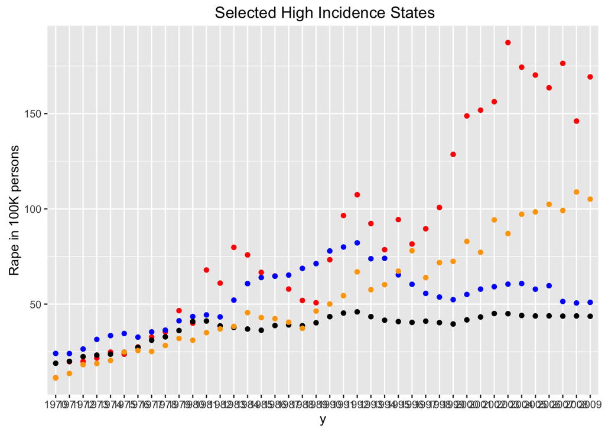

```r
# So Alaska is high. This article tries to explain it is because of remoteness
# http://www.businessinsider.com/why-does-alaska-have-such-a-high-rate-rape-2013-9
# but that doesn't necessarily explain Michigan


# So have they always been high, or did others drop or what?

st_rape_pct %>% ggplot(aes(x = y)) + geom_point(aes(y=Alaska, col = "Alaska"), color = "red") + geom_point(aes(y=Michigan), color="blue") + geom_point(aes(y=California)) + geom_point(aes(y=New.Mexico), color = "orange") + labs(title = " Selected High Incidence States", y = "Rape in 100K persons" )
```

So the graph shows that some states, like California, did indeed follow the pattern of peaking in 1990, while certain states, like Alaska and New Mexico are less clear.

But, does murder rate follow the same pattern?

```r
# state murder table
st_murder <-read.csv("Sources/ucr-us-murder-by-state1960-2012a.csv")
st_murder$year <- as.character(st_murder$year)
st_murder <- st_murder %>% filter(year >= 1970 & year <= 2009) %>% select(-United.States.Total)

#Create a table of pct/1000 people for murders
y <- st_murder$year
st_murder_y <- st_murder %>% select(-year)
st_pop_y <- st_pop %>% select(-year) * 1000
st_murder_pct <- st_murder_y/st_pop_y * 100000
st_murder_means <- st_murder_pct %>% colMeans()

st_murder_means <- data.frame(st_murder_means)
st_murder_means <- add_rownames(st_murder_means, "state")

#Restore the percent table for later
st_murder_pct <- data.frame(y,st_murder_pct)


#join it to the rape figures and show it
st_crime_means <- st_crime_means %>% left_join(st_murder_means, by = 'state')
arrange(st_crime_means, desc(st_murder_means)) %>% kable()
```

| state | st_rape_means | st_murder_means |
| --- | --- | --- |
| District.of.Columbia | 54.91789 | 41.598147 |
| Nevada | 77.73682 | 14.593527 |
| Louisiana | 35.51272 | 14.114186 |
| Arizona | 49.79750 | 11.209244 |
| Mississippi | 32.67671 | 11.141197 |
| Georgia | 34.69296 | 10.578981 |
| Alabama | 31.00017 | 10.371063 |
| Texas | 44.08898 | 10.285709 |
| New.Mexico | 55.24157 | 10.240512 |
| Maryland | 33.23506 | 10.146408 |
| South.Carolina | 43.51782 | 9.805069 |
| California | 37.70260 | 9.517431 |
| Florida | 50.36634 | 9.420268 |
| Tennessee | 40.37798 | 9.216636 |
| Michigan | 53.41993 | 9.048941 |
| North.Carolina | 28.08276 | 9.009207 |
| New.York | 24.32159 | 8.942457 |
| Illinois | 32.75774 | 8.927686 |
| Alaska | 86.67390 | 8.807615 |
| Arkansas | 35.80322 | 8.499360 |
| Missouri | 28.87396 | 8.347995 |
| Virginia | 26.71843 | 7.570261 |
| Oklahoma | 39.89663 | 7.296650 |
| Kentucky | 26.49059 | 6.985870 |
| Indiana | 29.54018 | 6.560779 |
| Ohio | 36.56161 | 5.833128 |
| Pennsylvania | 24.03875 | 5.775584 |
| Colorado | 48.63893 | 5.453917 |
| West.Virginia | 17.06566 | 5.193441 |
| Kansas | 34.62700 | 5.188678 |
| New.Jersey | 22.33409 | 5.143758 |
| Delaware | 52.81392 | 4.970459 |
| Washington | 50.90478 | 4.299543 |
| Wyoming | 27.76283 | 4.206259 |
| Connecticut | 20.52217 | 4.077896 |
| Hawaii | 31.64863 | 4.029398 |
| Oregon | 41.95127 | 3.937182 |
| Montana | 24.49916 | 3.641284 |
| Wisconsin | 18.84400 | 3.338357 |
| Rhode.Island | 24.22270 | 3.299840 |
| Massachusetts | 26.33173 | 3.229388 |
| Nebraska | 24.95806 | 3.216307 |
| Idaho | 32.05711 | 3.189435 |
| Utah | 41.21309 | 3.108959 |
| Minnesota | 35.99148 | 2.613929 |
| Vermont | 23.82054 | 2.300683 |
| South.Dakota | 33.30910 | 2.189261 |
| Maine | 19.73123 | 2.143010 |
| Iowa | 18.39501 | 1.924306 |
| New.Hampshire | 28.63779 | 1.892031 |
| North.Dakota | 18.35786 | 1.311604 |

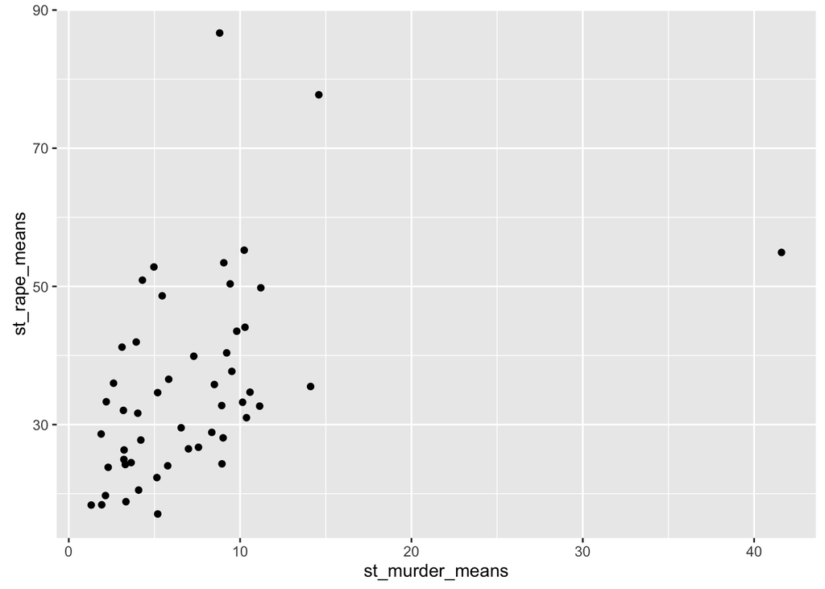

```r
st_crime_means %>% ggplot(aes(st_murder_means,st_rape_means)) + geom_point()
```

```r
cor(st_crime_means$st_rape_means,st_crime_means$st_murder_means)
```

```
## [1] 0.4400613
```

```r
cor.test(st_crime_means$st_rape_means,st_crime_means$st_murder_means)
```

```
##
##  Pearson's product-moment correlation
##
## data:  st_crime_means$st_rape_means and st_crime_means$st_murder_means
## t = 3.4304, df = 49, p-value = 0.001232
## alternative hypothesis: true correlation is not equal to 0
## 95 percent confidence interval:
##  0.1871774 0.6382429
## sample estimates:
##       cor
## 0.4400613
```

So, there is some level of correlation, but it doesn’t look like enough to predict it reliably.

The best would be to check year-by-year state data, but this is not readily avaiable. But we can do a spot check of certain years of state data and see if the median age has any relationship to rape percentage. The year 2009 is available in the data.

#### from Sameen

1. upload state wide data; explain data cleaning process both manual and R.
2. do a graph for each demographic and crime rate for ALL states for the most current year.
3. single out top 4 and bottom 4 states with worst crime rate and show a chart of them.
4. show graphs using facet_wrap for top 4 states and the demographics data for current year, for over time; then for bottom 4;
5. any correlations between the demographics for top 4 states? for bottom 4 states? do comparisons between the top 4 states to see trends. do you notice any trends between top 4 states data vs bottom 4’s data in terms of which demographics jump out at you?

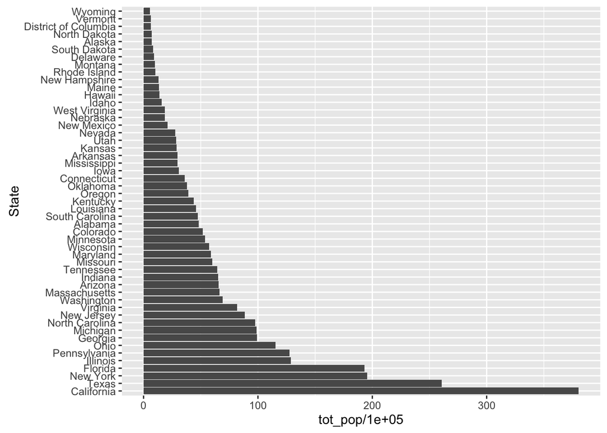

```r
# State data for 2012 compiled from multiple  American Community Survey tables (US Census Bureau) and from the FBI Uniform Crime Reporting database.

stdem <- read.csv("states-key-demographics-2012.csv")

# Population by state
stbypop <- stdem %>% arrange(desc(tot_pop))
stbypop$State <- factor(stbypop$State, levels = stbypop$State)
stbypop %>% ggplot(aes(x= State, y = tot_pop/100000)) + geom_bar(stat = "identity") + coord_flip()
```

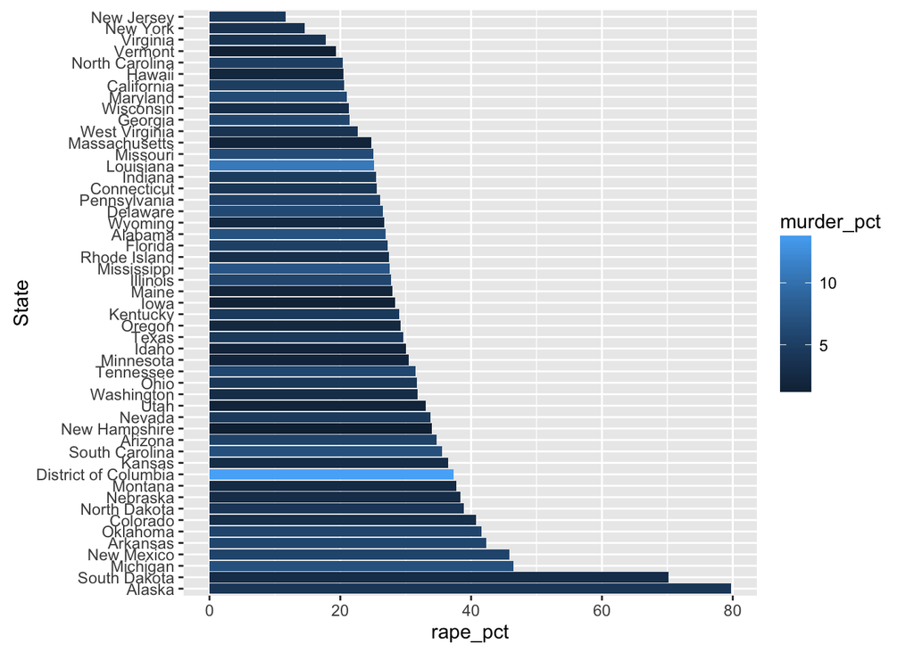

```r
# Murder and Rape percent by State
stcrime <-stdem
stcrime <- stcrime %>% mutate(rape_pct = num_rapes/tot_pop * 100000, murder_pct = num_murder/tot_pop * 100000)
stcrime <- stcrime %>% arrange(desc(rape_pct))
stcrime$State <- factor(stcrime$State, levels = stcrime$State)

# Make the graph for rape and murder
stcrime %>% ggplot(aes(x= State, y = rape_pct, fill = murder_pct)) + geom_bar(position='dodge',stat = "identity") + coord_flip()
```

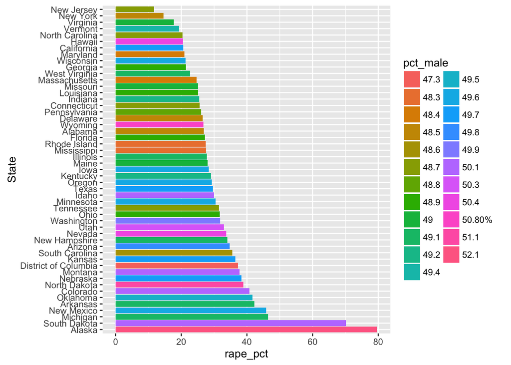

```r
# Percent of males
stcrime %>% ggplot(aes(x= State, y = rape_pct, fill = pct_male)) + geom_bar(position='dodge',stat = "identity") + coord_flip()
```

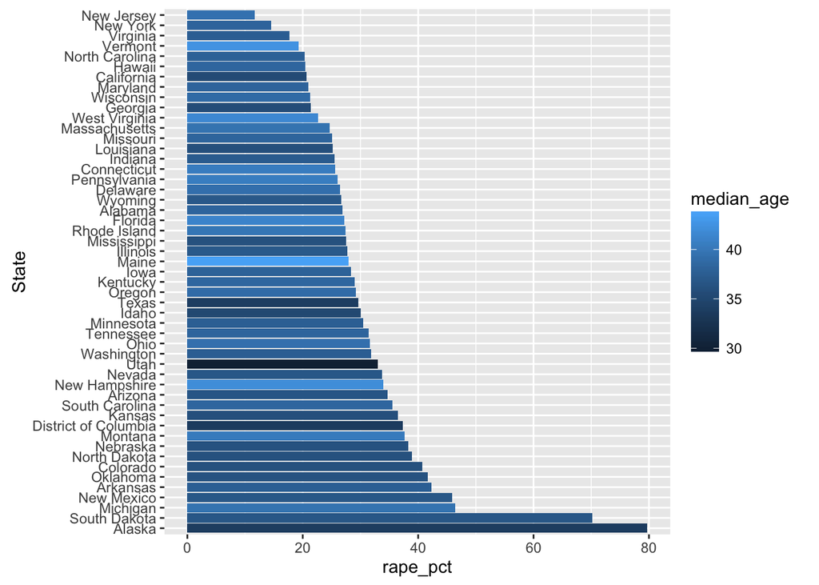

```r
# Median age
stcrime %>% ggplot(aes(x= State, y = rape_pct, fill = median_age)) + geom_bar(position='dodge',stat = "identity") + coord_flip()
```

[figure not shown]

```r
# Average Income
stcrime %>% ggplot(aes(x= State, y = rape_pct, fill = pct_male)) + geom_bar(position='dodge',stat = "identity") + coord_flip()
```

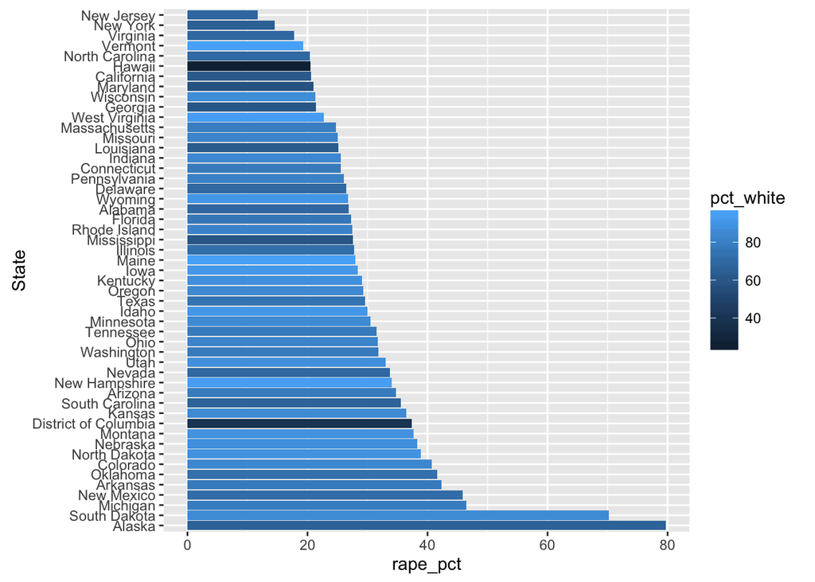

```r
# Racial Mix
stcrime %>% ggplot(aes(x= State, y = rape_pct, fill = pct_white)) + geom_bar(position='dodge',stat = "identity") + coord_flip()
```

```r
# Educational attainment vs rape

# Prevalence of single family households

# Top four and bottom four



#stdem %>% ggplot(aes(x = pct * 100000,y = State)) + geom_point()
```

```r
# create the table doing a little mechanical transpose of one column
st_pop <- read.csv("Sources/12s0013-residents-state-1960-2009.csv")
st_pop$State <- as.character(st_pop$State)
st_pop <- st_pop %>% select(State,X2009)
st_rape <- read.csv("Sources/ucr-us-rape-by-state1960-2012a.csv")
st_rape <- st_rape %>% filter(year == 2009) %>% select(-year, -United.States.Total)
states <- names(st_rape)
pct <- unlist(st_rape)
rpct <- pct/st_pop$X2009 * 100
stat09 <- data.frame(rpct)
stat09 <- add_rownames(stat09,"State")

# table showing top rape count for 2009
arrange(stat09,desc(rpct)) %>% kable
```

| State | rpct |
| --- | --- |
| Alaska | 73.49570 |
| South.Dakota | 61.69951 |
| New.Mexico | 53.18408 |
| Arkansas | 47.69817 |
| North.Dakota | 45.74961 |
| Michigan | 45.37613 |
| Colorado | 45.15423 |
| Delaware | 44.63277 |
| Kansas | 41.82334 |
| Oklahoma | 41.63276 |
| Washington | 38.76050 |
| Nevada | 38.74385 |
| Idaho | 37.19276 |
| Montana | 36.61538 |
| South.Carolina | 36.46130 |
| Ohio | 35.68396 |
| Kentucky | 35.48911 |
| Arizona | 34.55124 |
| Nebraska | 34.33500 |
| Minnesota | 33.97265 |
| Utah | 33.78815 |
| Mississippi | 33.57046 |
| Texas | 33.53644 |
| Tennessee | 32.06798 |
| Alabama | 31.93884 |
| Wyoming | 31.61765 |
| Oregon | 31.41662 |
| Illinois | 30.21689 |
| New.Hampshire | 30.11321 |
| Louisiana | 30.07569 |
| Hawaii | 29.72973 |
| Florida | 29.67418 |
| Iowa | 29.58777 |
| Pennsylvania | 28.76636 |
| Maine | 28.45220 |
| Rhode.Island | 28.11016 |
| Missouri | 26.82031 |
| Massachusetts | 26.29663 |
| West.Virginia | 25.82418 |
| Indiana | 25.23743 |
| District.of.Columbia | 25.00000 |
| North.Carolina | 24.58160 |
| Georgia | 23.63414 |
| California | 23.57286 |
| Vermont | 21.22187 |
| Maryland | 20.28426 |
| Virginia | 19.94165 |
| Wisconsin | 19.77011 |
| Connecticut | 18.67538 |
| New.York | 13.21324 |
| New.Jersey | 11.95452 |

```r
# for writing out the df that will be used in choropleth
#stat09a <- stat09 %>% filter(State != 'District.of.Columbia')
#write.csv(stat09a, file = "state_rape_percent_2009.csv")

# acs.fetch(geography=washington, endyear = "2011", table.number="B01003")
```

So this gives a list of the states with the highest percentage. We now need the median ages. For this, we go on to several packages that pull from the UScensus data. These are

UScensus2010 acs choroplethr

These will be used to drill down into state and maybe even county data. The packages enable both efficiently pulling the numbers and making interesting visuals.

```r
# install.packages("devtools")
# inspired by - See more at: http://www.trulia.com/blog/tech/the-choroplethr-package-for-r/
# can be installed from CRAN
# USCensus API key needed install one time. To obtain: http://api.census.gov/data/key_signup.html to get the key
# then api.key.install(key="592bc14cnotarealkey686552b17fda3c89dd389") (example)
# see http://eglenn.scripts.mit.edu/citystate/wp-content/uploads/2013/06/wpid-working_with_acs_R3.pdf for acs package info.

#library(choroplethr)
#library(acs)
#library(choroplethrMaps)
#data("state.map")

#Median age of Males
#will not knit because it asks interactively for table number
# state_choropleth_acs(tableId="B01002")

# rape Pct Graphic
#df <- read.csv("state_rape_percent_2009.csv")
#state_choropleth(df, title = 'Rape Pct 2009')

# median age graphic
#cf <- read.csv("Sources/state-media-age-2010.csv")
#state_choropleth(cf, title = 'Median Age 2010')

#Note: You can see intuitively flipping between the maps that there could be a correspondence of age and rape pct.

# although a minor negative correlation? (rape pct down as median age up) Size of certain male age groups would be better probably

#qf <- left_join(df,cf, by = 'region')
#qf %>% ggplot(aes(x = value.x)) + geom_point(aes(y= value.y))
#cor.test(qf$value.x,qf$value.y)
```

We could also look at this for example at the census tract level within a state or city.NOTE: Not sure about using this, but still checking it can rovide a useful view.

SUMMARY This inquiry showed some of the possibilities and pitfalls in exploting demographics in the United States. While the US Census Bureau has a vast database spanning decades and centuries of data, it is not particularly homogenous and times have changed so that assumptions about what was relevant in the early 1900s are different from what is relevant today. The labels change, the years covered change, there are gaps. Table cols and rows always transposed. there are a bunch of footnotes and assumptions made, would probably need to re-examine the effect at some point

This inquiry has shown examples from the national and state levels and how the data might be extracted and visualized.

Although some trends and correlations were shown, it would be premature to draw man conclusions from just that. There are many confounding factors and assumptions.